# Bike Sharing Analysis with Ford GoBike Data by Eda Sanli

## Explanatory Analysis Questions

### What kind of development trend do we see on bike rides?

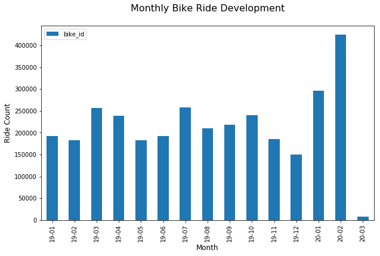

```python
#let's truncate the hour to aggregate bike rides by month.
df_clean['start_time_year_month'] = df_clean['start_time'].dt.strftime('%y' + '-' + '%m')

#Then create a new dataframe by grouping by start_time_dat on bike trip count
daily_bike_rides  = pd.DataFrame(df_clean.groupby('start_time_year_month')['bike_id'].count())
daily_bike_rides.sort_values('start_time_year_month').plot(kind='bar', figsize = (10,6));
plt.title('Monthly Bike Ride Development\n', size = 16);
plt.xlabel('Month', size = 12);
plt.ylabel('Ride Count', size = 12);
```

### On which week days do we observe more rides?

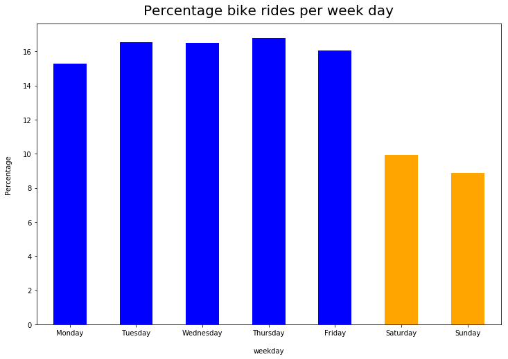

```python
weekday_trips = df_clean.groupby('weekday').agg({'bike_id':'count'})
weekday_trips['perc'] = (weekday_trips['bike_id']/weekday_trips['bike_id'].sum())*100
weekday_index = ['Monday', 'Tuesday', 'Wednesday', 'Thursday', 'Friday', 'Saturday', 'Sunday']

colors = ['blue', 'blue', 'blue', 'blue', 'blue', 'orange', 'orange']
weekday_trips.reindex(weekday_index)['perc'].plot(kind='bar', color=colors, figsize=(12,8), legend=False)
plt.title('Percentage bike rides per week day', fontsize=20, y=1.015);
plt.xlabel('weekday', labelpad=16);
plt.ylabel('Percentage', labelpad=16);
plt.xticks(rotation=360);
```

Although we might have expected that bike rides should increase on the weekends (maybe they go out with their friends, families, spend more time outside, etc), we actually see a drop in the weekends, whereas Mon-Fri usage is almost equally distributed to the week.

This is an interesting point and we will do a further investigation on this.

### On which week day/ hour of the day do we observe more rides?

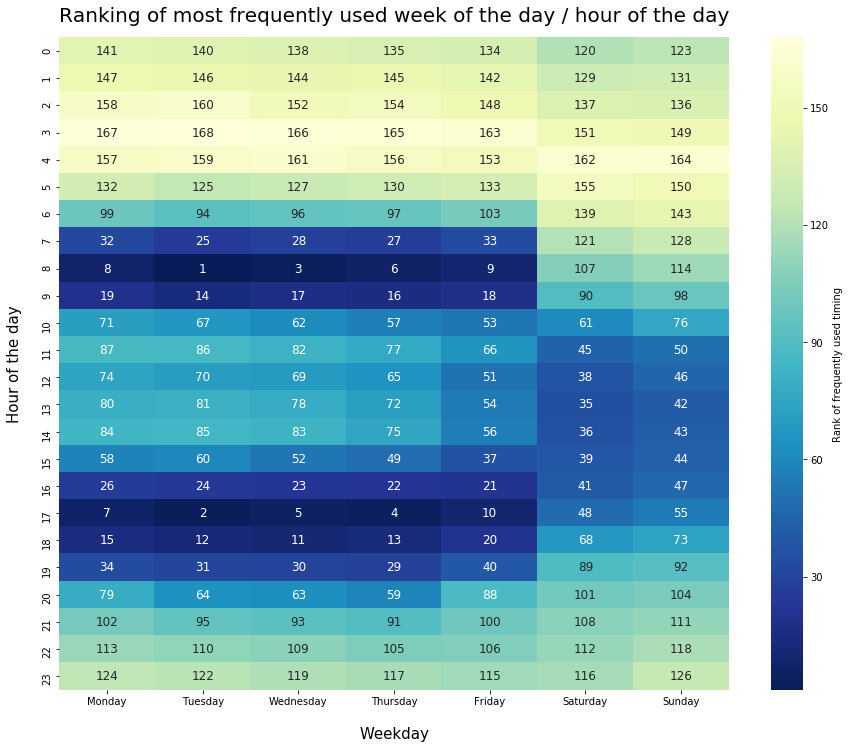

```python
plt.figure(figsize=(15,12))
sb.heatmap(hour_df_pivoted, fmt='d', annot=True, cmap='YlGnBu_r', annot_kws={"size": 12}, cbar_kws={'label': 'Rank of frequently used timing'});
plt.title("Ranking of most frequently used week of the day / hour of the day", y=1.015, size = 20);
plt.xlabel('Weekday', labelpad=20, size = 15);
plt.ylabel('Hour of the day', labelpad=20, size= 15);
```

In the previous plot, we have observed that users prefer to use bike-sharing system during the day than the weekend. When we check this heatmap above, we can see that the most frequently used time slots are before and after working hours. Therefore, here we can interpret that people use this system not only to go from point A to B on leisure time, but also as a communiting system in their daily life during the week.

Weekend usage however shows us a different side of bike sharing system. While people rent bike during the week between7-9 and 17-20 during the week, we see a slight increase on bike rides during the weekend, between 12 - 3 (comparing to the same time slots during the week). This shows us the fact that people actually use bike sharing system not only on work-related commuting, but also for their free time during the weekend.

### Which user types have been growing over the last months?

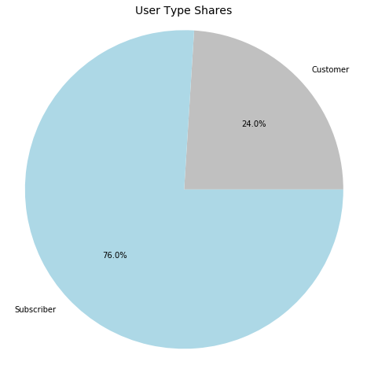

```python
fig = plt.gcf()
fig.set_size_inches(8,8)

my_colors = ['silver','lightblue']
shares= [customer_share, subscriber_share]
user_labels = 'Customer','Subscriber'
plt.pie(shares ,labels=user_labels,autopct='%1.1f%%', colors = my_colors)
plt.title('User Type Shares', size = 14)
plt.axis('equal')
plt.show()
```

In the pie chart above, we can see that subscribers have a dominancy and make 76% of the total bike rides in 2019 and 2020 year to March.

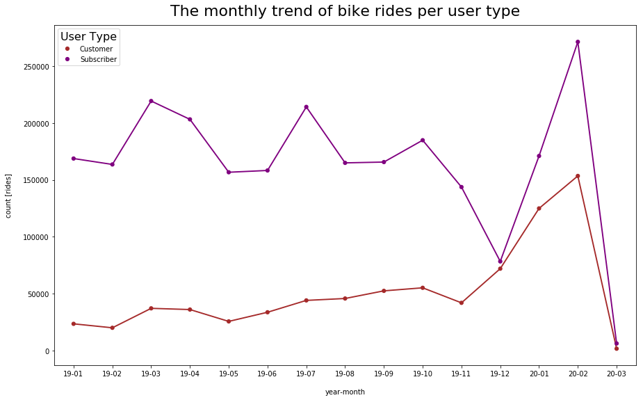

```python
plt.figure(figsize=(15,9))
my_palette = {'Subscriber':'purple', 'Customer':'brown'}
ax = sb.pointplot(x='start_time_year_month', y=0, hue='user_type', palette=my_palette, scale=.7, data=user_type_count_per_year_df)
plt.title('The monthly trend of bike rides per user type', fontsize=22, y=1.015)
plt.xlabel('year-month', labelpad=16)
plt.ylabel('count [rides]', labelpad=16)
leg = ax.legend()
leg.set_title('User Type',prop={'size':16})
ax = plt.gca()
```

In order to have a more profound understanding, here we go a step further and analyse user type behaviors in given time period.

Here above we compare subscribers and customers historical development over the last year. There have been a significant gap between two types until Dec'19, however we observe a small shrink by the end of the last quarter of 2019.

Two points' joining in Dec'19 does not have to be specifically interpreted as Fordgo is losing its subscribers, but can be explained with Christmas period and off time. 2020 first two months' trend can support this argument.

### Do we see different behaviours on the week of the day/hour of the day between subscribers and customers?

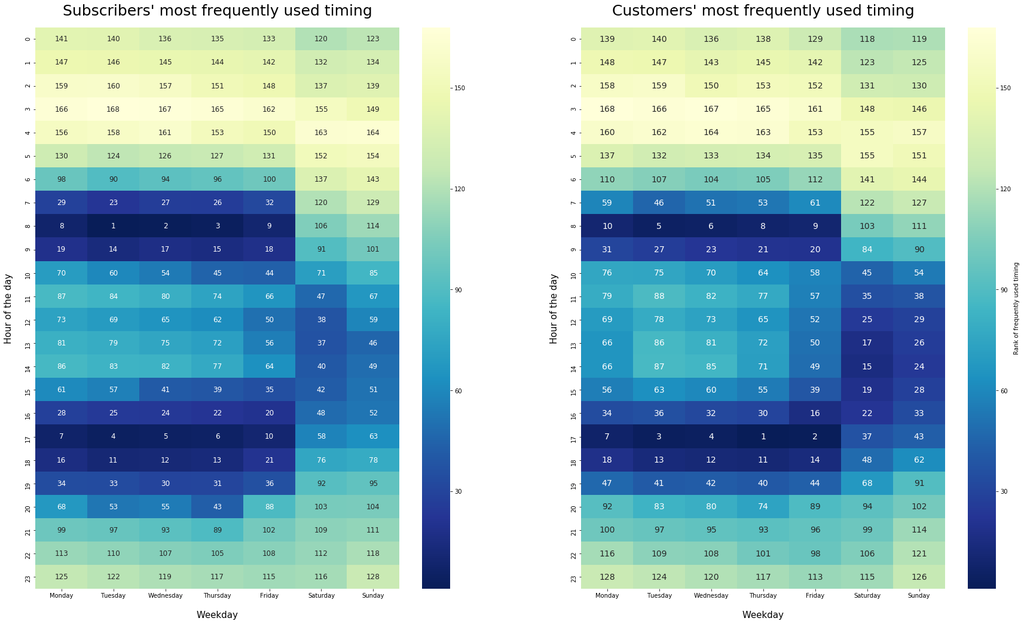

```python
# 1st plot: subscribers
plt.figure(figsize=(30,38))

plt.subplot(221)
sb.heatmap(subscriber_hour_df_pivoted, fmt='d', annot=True, cmap='YlGnBu_r', annot_kws={"size": 12});
plt.title("Subscribers' most frequently used timing", y=1.015, size = 25);
plt.xlabel('Weekday', labelpad=20, size = 15);
plt.ylabel('Hour of the day', labelpad=20, size= 15);

# 2nd plot: customers
plt.subplot(222)
#plt.figure(figsize=(15,12))
sb.heatmap(customer_hour_df_pivoted, fmt='d', annot=True, cmap='YlGnBu_r', annot_kws={"size": 14}, cbar_kws={'label': 'Rank of frequently used timing'});
plt.title("Customers' most frequently used timing", y=1.015, size = 25);
plt.xlabel('Weekday', labelpad=20, size = 15);
plt.ylabel('Hour of the day', labelpad=20, size= 15);
```

To understand user type behaviors in broader manner, we create two heatmaps showing the day of the week, hour of the day and rank of the bike ride count for each user type.

As a result, we might that say subscribers do subscribe this system for daily communting to school or work.

### What is the average trip duration per user group?

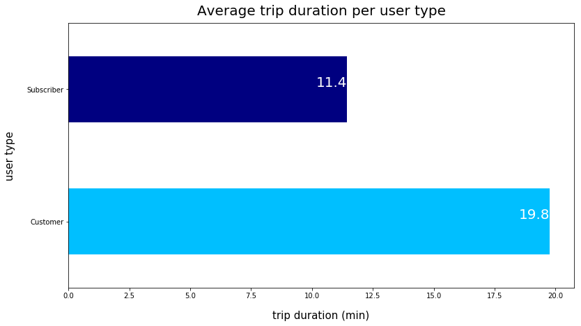

```python
df_clean['duration_min'] = df_clean['duration_sec'] / 60

new_color = ['deepskyblue','navy']
ax = df_clean.groupby(['user_type'])['duration_min'].mean().plot(kind='barh',color = new_color,figsize = (13,7));
[ax.text(v, i, '{:.1f}'.format(v), fontsize=20, horizontalalignment='right', verticalalignment = 'bottom', color='white') for i, v in enumerate(df_clean.groupby(['user_type'])['duration_min'].mean())];
ax.set_title('Average trip duration per user type', fontsize=20, y=1.015)
ax.set_ylabel('user type', labelpad=16, size = 15)
ax.set_xlabel('trip duration (min)', labelpad=16, size =15);
```

When we split average trip duration values to user types, we can observe that subscribers take bike trips for short duration (11.4 mins) whereas customers take it for almost twice the duration (19.8 min)

### What is the average trip distance per user group?

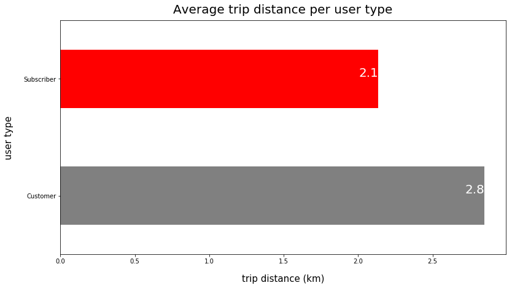

```python
new_color = ['grey','red']
ax = df_clean.groupby(['user_type'])['distance_km'].mean().plot(kind='barh',color = new_color,figsize = (13,7));
[ax.text(v, i, '{:.1f}'.format(v), fontsize=20, horizontalalignment='right', verticalalignment = 'bottom', color='white') for i, v in enumerate(df_clean.groupby(['user_type'])['distance_km'].mean())];
ax.set_title('Average trip distance per user type', fontsize=20, y=1.015)
ax.set_ylabel('user type', labelpad=16, size = 15)
ax.set_xlabel('trip distance (km)', labelpad=16, size =15);
```

Similar with trip duration plot, we see different behaviors between user types, where customers use bike sharing system for comparably longer distance trips (2.8 km) than subscribers (2.1 km)

### Who is faster rider, subscribers or customers?

```
Subscribers ride 0.25 km per min, whereas customers ride 0.16 km per min
```

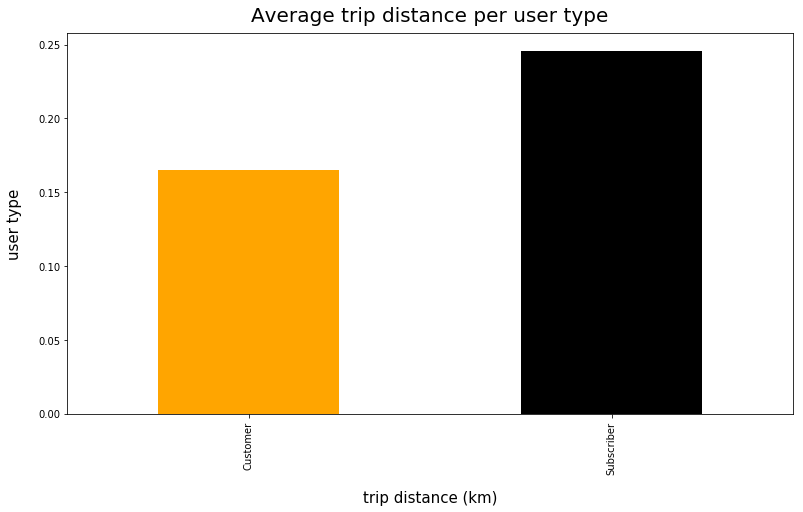

```python
print('Subscribers ride {} km per min, whereas customers ride {} km per min\n'.format(subscriber_speed, customer_speed))
new_color = ['orange','black']
ax = df_clean.groupby(['user_type'])['speed/min'].mean().plot(kind='bar',color = new_color,figsize = (13,7));
ax.set_title('Average trip distance per user type', fontsize=20, y=1.015)
ax.set_ylabel('user type', labelpad=16, size = 15)
ax.set_xlabel('trip distance (km)', labelpad=16, size =15);
```

When we analyse each user type's speed per min, we can clearly see that subscribers ride 1.5 times faster than customers (and we can say that this is because they use bike rides more functionally, such as daily commuting)

### How rental access methods behave differently in each user type?

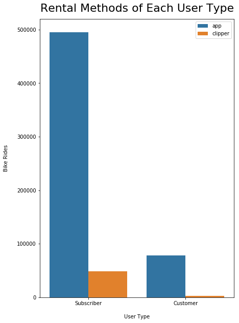

```python
cat2_order = ['app', 'clipper']
cat1_order = ['Subscriber', 'Customer']

plt.figure(figsize = [15, 10])

# left plot: clustered bar chart, absolute counts
plt.subplot(1, 2, 1)
ax = sb.countplot(data = df_clean_rental, x = 'user_type', hue = 'rental_access_method',
             order = cat1_order, hue_order = cat2_order);

plt.title('Rental Methods of Each User Type', fontsize=22, y=1.015)
plt.xlabel('User Type', labelpad=16)
plt.ylabel('Bike Rides', labelpad=16)
plt.legend();
```

As we can observe, a big majority of the people use app than clipper.

91% of the subscribers use app and this share increase to 97% for customers.

### What kind of trend do we observe on Bike Share for All users?

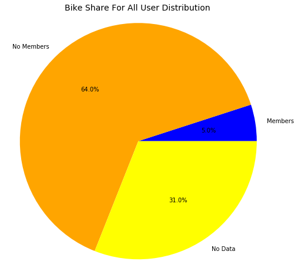

```python
fig = plt.gcf()
fig.set_size_inches(8,8)

my_colors = ['blue','orange', 'yellow']
shares= [bikeshareforall_share, non_bikeshareforall_share, no_member_data]
user_labels = 'Members','No Members', 'No Data'
plt.pie(shares ,labels=user_labels,autopct='%1.1f%%', colors = my_colors)
plt.title('Bike Share For All User Distribution', size = 14)
plt.axis('equal')
plt.show()
```

## Summary

Since there was a variable scarcity with the new update in the dataset, I checked the different behaviours between user types like subscribers and customers (non subscribers).